# Project3

Jiaming Qu

11/17/2019

## Background Introduction

The data set is kindly provided by Urban Ministries of Druham, which records their assistance and help to people each year. Different from Project 1 which includes services in many aspects, this project focuses on the shelter service with detailed information of clients and service records. In this project, I am going to explore how the shelter services influence clients and find the hidden trends.

## Research Question

### Section 1. Deomographic data analysis of our clients.

#### 1.1 How old are our clients when they come to the shelter?

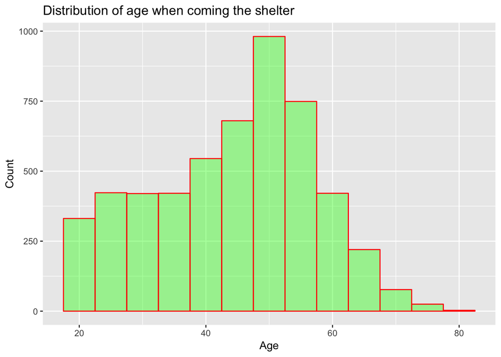

It shows that people’s ages when coming to the shelter nearly follows a normal distribution, with centering between 40 to 60 years old.

#### 1.2 What about gender and race?

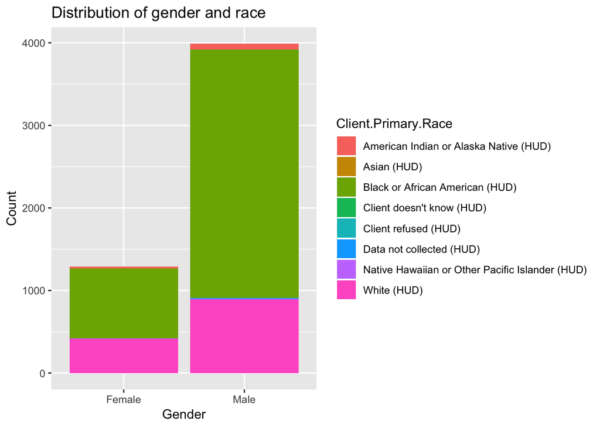

It shows that there are more male clients than female clients (4000 vs near 1000). Also we could see the most clients are Black or African American, followed by White.

## Behavior Analysis

### 2.1 How long does our clients stay in the shelter everytime when they come?

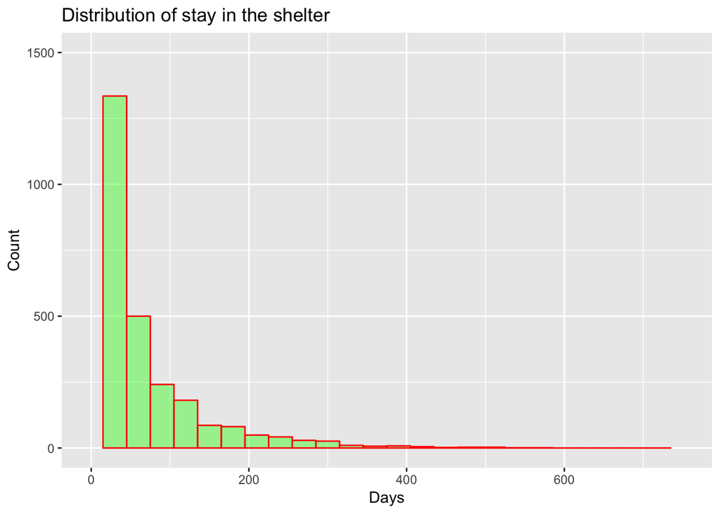

It shows that most people stay under 100 days in the shelter with few up to 250 days everytime when they come to the shelter.

### 2.2 Are there any correlations between people’s age when coming to the shelter and their length of stay?

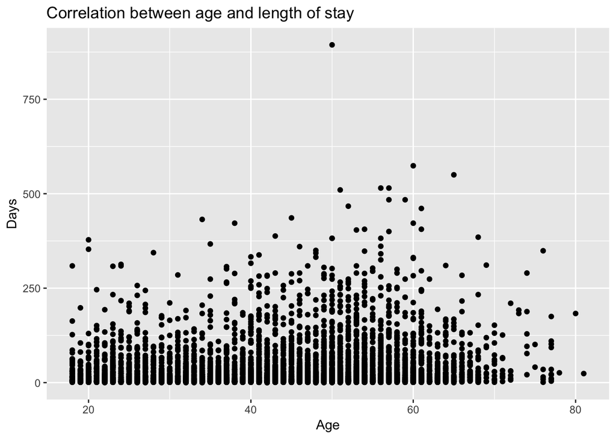

We do not see a positive correlation between age and length of stay, my hypothesis that the older people are when they come to the shelter, the longer they will stay is proved to be wrong.

### 2.3 Do our clients come back to our shelter after they leave?

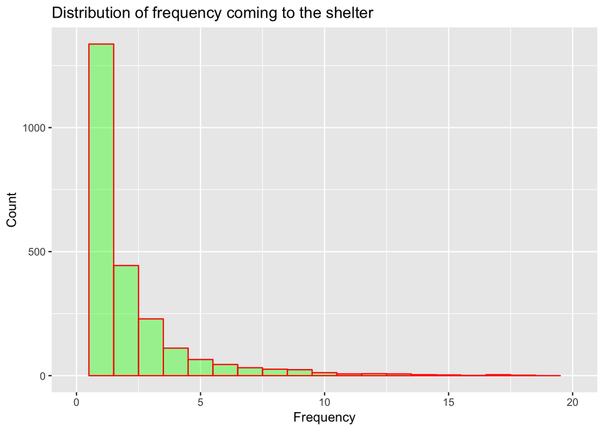

It shows that most people only come under 3 times to our shelter, with 1 time as the most. Therefore we might prepare for someone’s coming back.

### 2.4 What month do clients like to come?

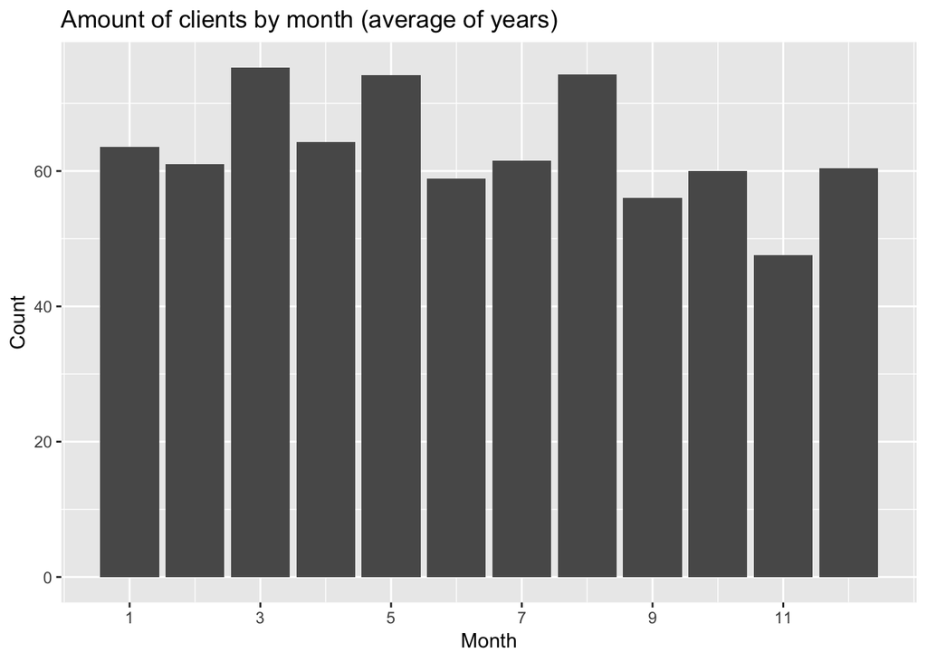

This indicates that on average of these years, there is no a particular month when our clients like to come. Three seasons have the most records, which are March, May and August. Thus, we need to parepare for these seasons and also all year round.

## 3. Other Information

### 3.1 How does the trend of people’s coming grow in general?

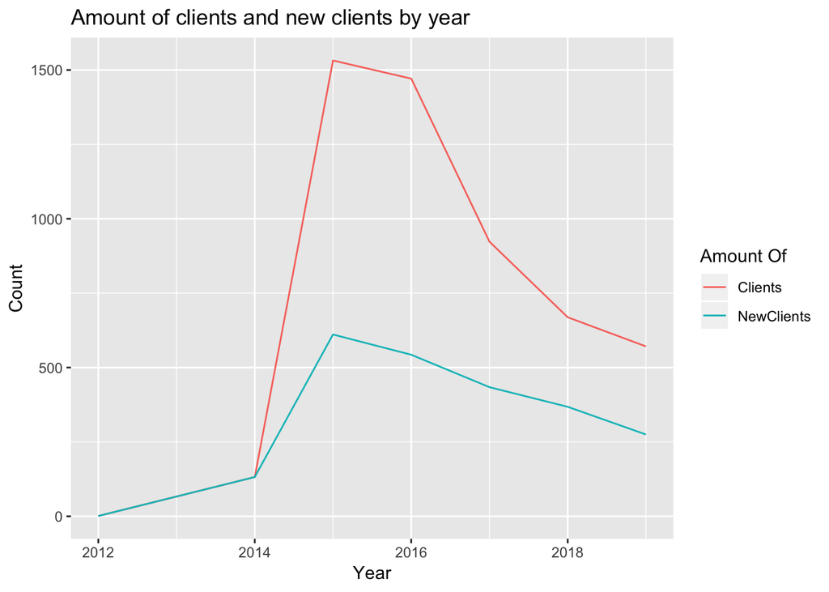

This figure shows that apart from 2012-2014, the general trends of clients and new clients coming to the shelter are decreasing.

### 3.2 Where do our clients go after they leave our shelter?

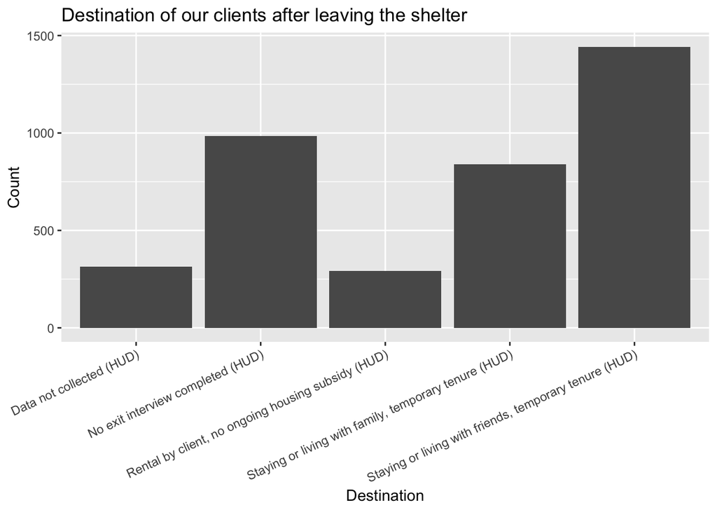

From the figure we could see the most impossible destination for our clients are staying or living with friends, followd by with family with exception of “No Interview” which is the 2nd place.

### 3.3 What are the reasons that make our clients leave the shelter?

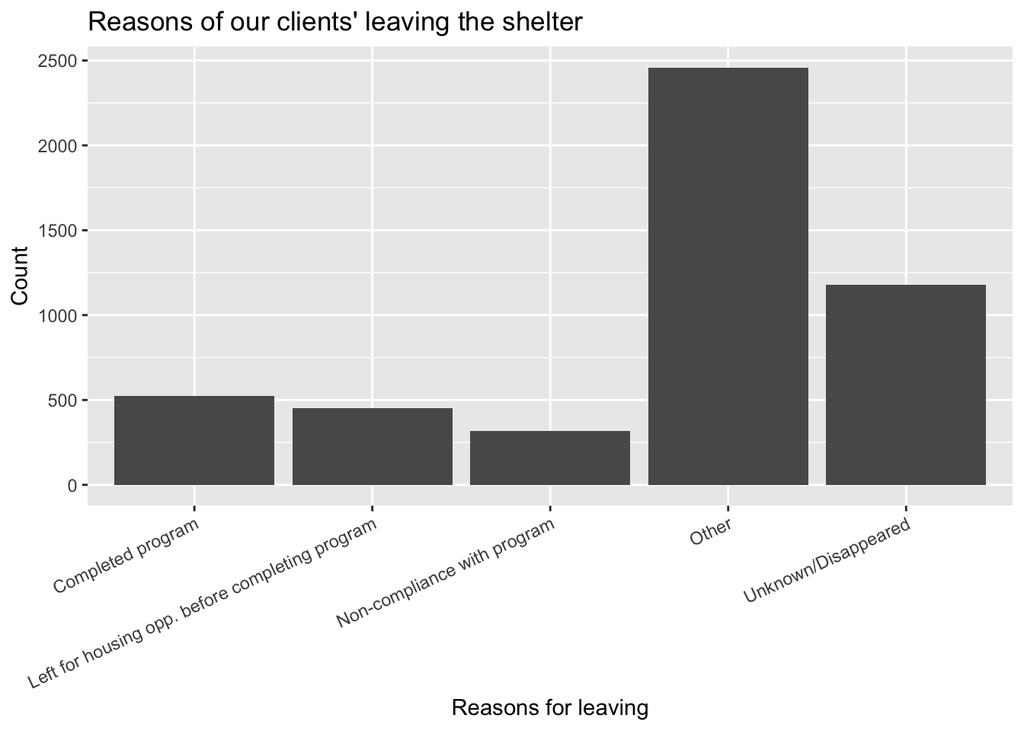

From the figure we could see the most impossible reasons for leaving are the completion of the program or left for housing, with exception of “Other” and “Unknown” which are the 1st and 2nd places.

### 3.4 Are there any correlations between clients’ destination and the reasons?

We use the Chi-squre test to test the correlation between two categorical data.

Top 10 positive correlation:

```
## [1] "Destination: Deceased (HUD)  + Reason:  Death"
## [1] "Destination: No exit interview completed (HUD)  + Reason:  Unknown/Disappeared"
## [1] "Destination: Jail, prison or juvenile detention facility (HUD)  + Reason:  Criminal activity / violence"
## [1] "Destination: Place not meant for habitation (HUD)  + Reason:  Non-compliance with program"
## [1] "Destination: Rental by client, with other ongoing housing subsidy (HUD)  + Reason:  Completed program"
## [1] "Destination: Staying or living with friends, temporary tenure (HUD)  + Reason:  Other"
## [1] "Destination: Staying or living with family, permanent tenure (HUD)  + Reason:  Left for housing opp. before completing program"
## [1] "Destination: Data not collected (HUD)  + Reason:  Unknown/Disappeared"
## [1] "Destination: Rental by client, no ongoing housing subsidy (HUD)  + Reason:  Left for housing opp. before completing program"
## [1] "Destination: Rental by client, no ongoing housing subsidy (HUD)  + Reason:  Completed program"
```